# Stablcoin Analysis (Notebook)

This notebook loads data from **tables in the folder**, explores the columns, and draws common visualizations using **pandas**, **matplotlib**, and **seaborn**.

## 1) Executive Summary

Adoption is accelerating rapidly:

- Stablecoin transaction volumes reached **$18.4T** in 2024, surpassing Visa and Mastercard combined.
- Over **35M** unique addresses now use stablecoins (+50% YoY).
- Major institutions are entering: PayPal launched PYUSD, Visa is piloting USDC, and 22 large U.S. banks are exploring bank-issued digital dollars.

As this infrastructure matures, stablecoins offer SCF programs three critical advantages that traditional finance cannot easily replicate:

1. **Real-time, 24/7 settlement** for early-payment offers
2. **Ultra-low cross-border costs (<1%)**
3. **Access to global liquidity pools and DeFi yield markets**

The next sections use data to demonstrate why this transition is inevitable—and how SCF platforms can benefit strategically.

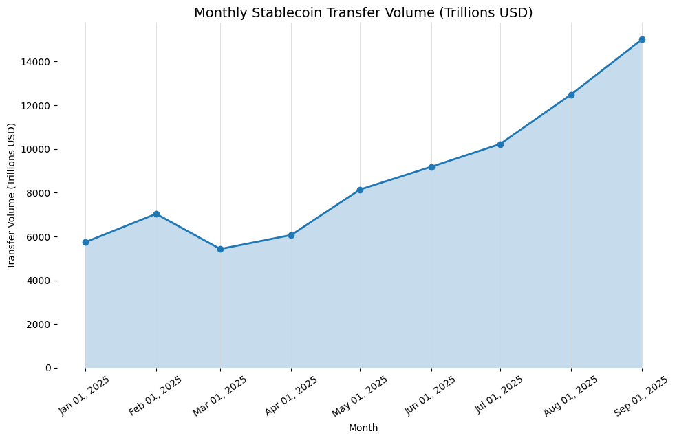

According to [ChainCatcher](https://www.chaincatcher.com/en/article/2165825)

## 2. Why Stablecoins Matter for SCF (Narrative + Data)

Traditional supply chain finance has delivered billions in liquidity to suppliers, but it still operates on rails that were built for a different era. Three long-standing constraints limit impact:

**1. Settlement bottlenecks (business hours only)** Suppliers wait 30–90+ days for early-payment offers to settle, especially across borders. This delay raises working-capital stress and increases the risk of stockouts or operational slowdown.

**2. High cross-border fees** Cross-border payments routinely incur 5–10% in fees, FX spreads, and intermediary costs—eroding margins for SMEs.

**3. Global financial exclusion** 40% of SME trade-finance applications are rejected (ADB, 2022), primarily due to:

- limited banking infrastructure
- expensive onboarding/KYC
- risk concerns
- slow settlement pipelines

Stablecoins directly address these challenges: real-time transfers, <1% fees, open access in 160+ countries, and automatic reconciliation via blockchain.

[figure not shown]

**Stablecoin Market Share Dynamics**

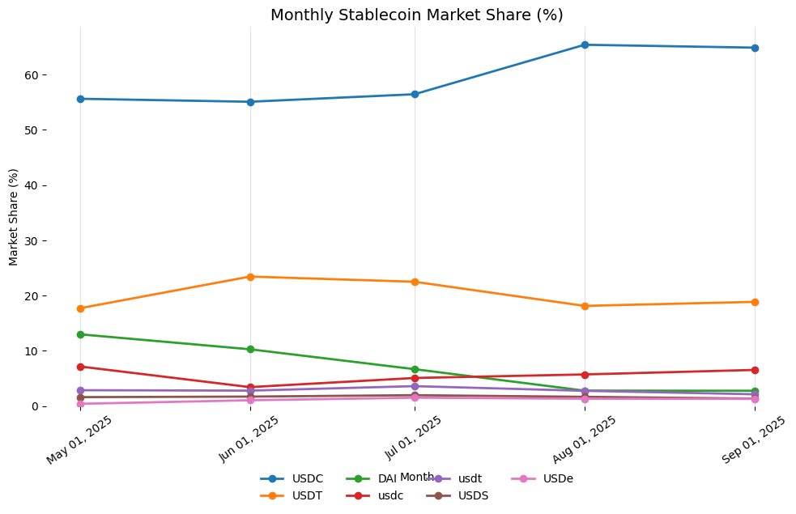

**Turnover: Stablecoins Are Used, Not Hoarded**

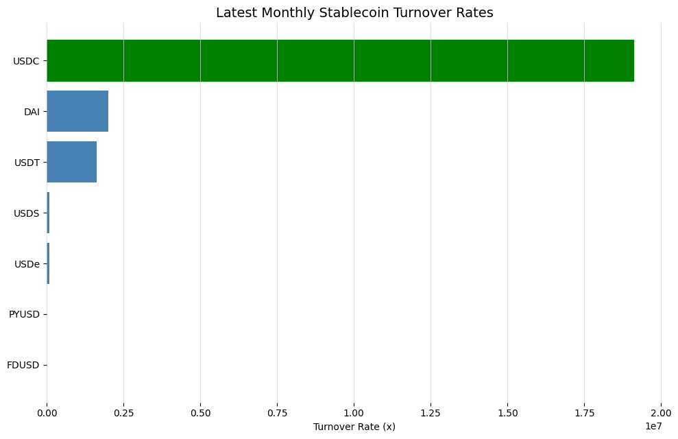

**Insight**: High turnover = stablecoins aren’t just stored; they move. For SCF, this is critical: liquidity needs to flow through suppliers, buyers, banks, and platforms with minimal friction.

## 3. Blockchain Ecosystem Dynamics: Where Stablecoin Activity Lives

This matters for SCF because:

- SCF requires **high throughput + low fees**
- settlement must be **predictable**
- corporate participants need **stable, regulated environments**

Below is the evolving chain distribution:

[figure not shown]

## 4. DeFi Liquidity: A New Funding Source for SCF

TradFi SCF funding is limited by balance sheets, risk mandates, and credit policies. But stablecoins unlock access to DeFi liquidity pools, where yield-seeking capital is abundant and global.

**Monthly DeFi Stablecoin Deposits**

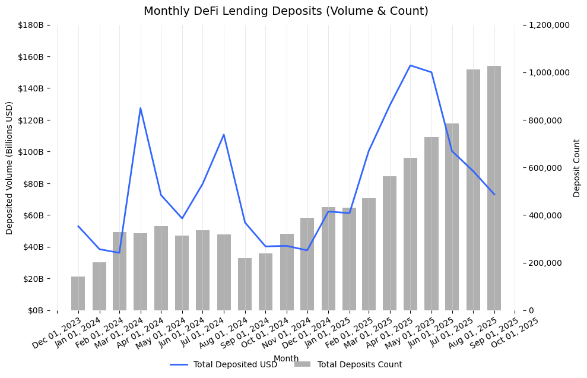

## 5. Key Risks, Barriers, and Mitigations

**1. Regulation** Regulatory clarity is improving. The **GENIUS Act (July 2025)** established a federal framework for **USD-backed stablecoins**, introducing 1:1 reserve requirements and Federal Reserve oversight for large issuers. This shift legitimizes stablecoins as part of the U.S. financial system, alleviating AML and consumer-protection concerns and paving the way for institutional adoption.

**2. Macroeconomic Environment** With Fed rate cuts reducing lending margins, SCF platforms face profitability pressures. Stablecoins offer a path to tap DeFi liquidity through **Real-World Asset (RWA) tokenization**, where supplier invoices are transformed into on-chain yield products. The RWA market, now $24B (2025), is expected to reach $2T by 2030, positioning SCF as one of the most scalable and tangible RWA applications.

**3. Technology Maturity** Stablecoin and blockchain infrastructure have evolved dramatically over the past 18–24 months:

- **Visa and Mastercard** are piloting real-time stablecoin settlements.
- **PayPal (PYUSD)** and Stripe signal blue-chip fintech adoption.
- **Ethereum’s upgrades** and Layer-2 scaling solutions have slashed fees and latency.
- Central-bank projects like **mBridge** validate blockchain for cross-border use.

  Together, these advancements create an ecosystem where regulations, infrastructure, and adoption align for scalable deployment.

[figure not shown]

## 6. How SCF Platforms Should Adopt Stablecoins (Strategy Roadmap)

**Phase 1 — Internal Research & Risk Alignment**

- Evaluate stablecoin issuers (USDC, PYUSD, GUSD)
- Work with compliance teams
- Build frameworks for supplier onboarding via stablecoins

**Phase 2 — Offer Stablecoin Payout Options**

- Allow suppliers to opt-in for early-payment settlement in USDC/PYUSD
- Begin with markets where banking rails are slow (LATAM, Africa, SEA)

**Phase 3 — Introduce RWA-Backed Financing Pools**

- Tokenize SCF invoices
- Allow DeFi lenders to provide liquidity
- Use over-collateralized pools + automated smart contract settlement

**Phase 4 — Hybrid TradFi × Web3 Operating Model**

- Stablecoins power backend settlement
- User experience remains simple (no crypto expertise needed)
- SCF platforms gain global reach + lower cost structure

## 7) Conclusion & Call to Action

Stablecoins are no longer experimental—they are a mainstream payment rail with billions in daily usage. For SCF platforms, they offer:

- Faster settlement
- Lower cross-border costs
- New liquidity sources
- Better access for SMEs in underserved regions

Regulators, fintech giants, and blockchain ecosystems are all moving in the same direction. SCF providers who embrace this shift will gain strategic advantage; those who wait risk becoming less competitive as suppliers and buyers migrate toward faster, cheaper alternatives.

Stablecoins represent the next evolution of global trade finance—and adoption in SCF is not a question of **if**, but **when**.

## 8) References

https://prima.trade/post/3-scf-pain-points https://coinspaidmedia.com/news/banks-and-fintech-companies-eye-stablecoin-market/ https://surecomp.com/blog/overcoming-top-trade-and-supply-chain-finance-challenges-with-tfaas/ https://uniteller.com/ut-blog/traditional-cross-border-payments-decline/ https://www.fxcintel.com/research/reports/ct-state-of-stablecoins-cross-border-payments-2025 https://ijerd.com/paper/vol20-issue11/2011673690.pdf https://www.rebank.cc/content/files/2025/05/Stablecoins-The-Practioners-Guide.pdf